# HAR - Correct Dumbbell Curl

Jason Murray

2017-02-27

## Summary

The tracking of individual activity using various sensors has become quite common. The purpose of this analysis is to find out whether we can identify not only the activity being performed from sensor data but whether it is being done correctly. If not being done correctly we would also like to identify in what way so proper feedback can be given to improve performace. For this we will use the weight lifting excersise dataset generously provided here: http://groupware.les.inf.puc-rio.br/har

The dataset includes sensor data collected from the arm, forearm, belt, and dumbbell. The particpants were asked to perform unilateral dumbbell bicep curl correctly as well as 4 incorrect movements while supervised by a trainer, for a total of 5 classes:

A - exactly according to specification  
B - throwing the elbows to the front  
C - lifting the dumbbell halfway  
D - lowering the dumbbell halfway  
E - Throwing the hips to the front

## Data Import and Cleaning

#### Required Libraries

```r
library(dplyr)
library(caret)
library(caretEnsemble)
library(parallel)
library(doParallel)
library(gbm)
library(randomForest)
library(kernlab)
```

#### Data Download and Import

The data for this analysis was obtained from the following locations:  
Training Data: https://d396qusza40orc.cloudfront.net/predmachlearn/pml-training.csv  
Testing Data: https://d396qusza40orc.cloudfront.net/predmachlearn/pml-testing.csv

```r
##Download location
train_url <- "https://d396qusza40orc.cloudfront.net/predmachlearn/pml-training.csv"
test_url <- "https://d396qusza40orc.cloudfront.net/predmachlearn/pml-testing.csv"

##Define local paths
data_dir <- "./data"
train_file <- paste(data_dir, "/pml-training.csv", sep = "")
test_file <- paste(data_dir, "/pml-testing.csv", sep = "")

##Commented after first download
#download.file(train_url,train_file)
#download.file(test_url,test_file)

##Import data
training <- read.csv(train_file, stringsAsFactors = FALSE)
testing <- read.csv(test_file, stringsAsFactors = FALSE)
```

#### Data Cleaning

First, let’s take a quick look at our data.

```r
str(training)
```

```
## 'data.frame':    19622 obs. of  160 variables:
##  $ X                       : int  1 2 3 4 5 6 7 8 9 10 ...
##  $ user_name               : chr  "carlitos" "carlitos" "carlitos" "carlitos" ...
##  $ raw_timestamp_part_1    : int  1323084231 1323084231 1323084231 1323084232 1323084232 1323084232 1323084232 1323084232 1323084232 1323084232 ...
##  $ raw_timestamp_part_2    : int  788290 808298 820366 120339 196328 304277 368296 440390 484323 484434 ...
##  $ cvtd_timestamp          : chr  "05/12/2011 11:23" "05/12/2011 11:23" "05/12/2011 11:23" "05/12/2011 11:23" ...
##  $ new_window              : chr  "no" "no" "no" "no" ...
##  $ num_window              : int  11 11 11 12 12 12 12 12 12 12 ...
##  $ roll_belt               : num  1.41 1.41 1.42 1.48 1.48 1.45 1.42 1.42 1.43 1.45 ...
##  $ pitch_belt              : num  8.07 8.07 8.07 8.05 8.07 8.06 8.09 8.13 8.16 8.17 ...
##  $ yaw_belt                : num  -94.4 -94.4 -94.4 -94.4 -94.4 -94.4 -94.4 -94.4 -94.4 -94.4 ...
##  $ total_accel_belt        : int  3 3 3 3 3 3 3 3 3 3 ...
##  $ kurtosis_roll_belt      : chr  "" "" "" "" ...
##  $ kurtosis_picth_belt     : chr  "" "" "" "" ...
##  $ kurtosis_yaw_belt       : chr  "" "" "" "" ...
```

[output cut: 86 more lines]

Right away we can see that are a lot of missing and NA values in our data. Let’s see how many lines are complete to see if we can figure out why this is.

```r
sum(complete.cases(training))
```

```
## [1] 406
```

Looking at the data it appears these are summary lines for each exercise window. So the columns with missing data appear to be filled for these entries only and look like summeries for each completed movement. There is a column labeled new_window, when set to yes it includes the summary data. Let’s double check this assumption by counting these lines.

```r
nw_yes <- training %>% filter(new_window=='yes')
dim(nw_yes)
```

```
## [1] 406 160
```

So this corresponds exactly to our complete cases. Looking at the testing data there are no summary lines. Based on this I’m not sure if the summary values are going to be of use in building a model to make predictions. Let’s clean up our data by keeping only the columns that have values for all entries. Let’s also exclude anything that isn’t likely to help us predict, including the index number, user_name, timestamps, and the window number. The selection below pulls all the columns that are complete and relevant to our analysis.

```r
##Filter out imcomplete and irrelevant columns
training <- training %>% dplyr::select(matches("^(roll|pitch|yaw|total_accel|gyros|accel|magnet|classe)"))
dim(training)
```

```
## [1] 19622    53
```

```r
sum(complete.cases(training))
```

```
## [1] 19622
```

So all the lines are now complete and we have reduced the columns from 160 to 53.

Let’s change the classe variable to a factor since we are classifying and declare our data clean.

```r
training$classe <- as.factor(training$classe)
```

In this analysis we are going to make final predictions on the test set once. I would like to try out a few different models to pick the best one before trying to make this prediction. In order to do that I’m going to hold 30% of the training data out to use for validation testing of my models.

```r
inTrain <- createDataPartition(training$classe, p = 0.7, list = F)
train <- training[inTrain,]
validation <- training[-inTrain,]
```

## Model Creation

Now let’s build a few models to try out on our validation data but first let’s turn on parallel processing to speed things up.

```r
## Set up parallel processing
cluster <- makeCluster(detectCores() - 1)
registerDoParallel(cluster)
```

For all of the models I will be using cross validation with 10 folds and 3 repeats. For each of the models I will also be searching for the best hyperparameters to use based on the dataset. I have choosen random forest, stochoastic gradient boosting, and radial svm as my models to test. I will select the best of the 3 to generate my final test predictions. I will rebuild the selected model(s) with all of the training data once I find the best one to maximize it’s performance on the test data.

#### Random Forest

```r
set.seed(50)
rf_ctrl <- trainControl(method = "repeatedcv", number = 10, repeats = 3, allowParallel=TRUE)
tunegrid_rf <- expand.grid(.mtry=c(6:12))
model_rf <- train(classe ~ ., data=train, method='rf', preProcess = c("center", "scale"), trControl = rf_ctrl, tuneGrid = tunegrid_rf)
```

On the first run I didn’t set the tuneGrid and it selected random values for mtry across a wide range. The model selected 2 as the best choice on the intial run but I wanted to see if there was something better near 2 so I ran again with 1-12 as possible values and it seemed to peak around 9 so I made another run with 6-12 as the range to see if I could find a better value. Here is a graph of their accuracy as well as the model info.

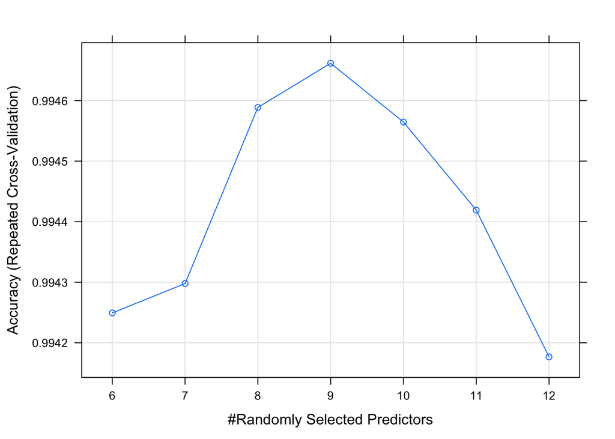

```r
plot(model_rf)
```

```r
model_rf
```

```
## Random Forest
##
## 13737 samples
##    52 predictor
##     5 classes: 'A', 'B', 'C', 'D', 'E'
##
## Pre-processing: centered (52), scaled (52)
## Resampling: Cross-Validated (10 fold, repeated 3 times)
## Summary of sample sizes: 12362, 12362, 12365, 12364, 12362, 12365, ...
## Resampling results across tuning parameters:
##
##   mtry  Accuracy   Kappa
##    6    0.9942493  0.9927253
##    7    0.9942979  0.9927867
##    8    0.9945888  0.9931547
##    9    0.9946617  0.9932471
##   10    0.9945646  0.9931243
##   11    0.9944192  0.9929402
##   12    0.9941766  0.9926336
##
## Accuracy was used to select the optimal model using  the largest value.
## The final value used for the model was mtry = 9.
```

The final selected mtry was 9. It seem to peak there and gradually drop off afterwards so I think it’s the best value to use.

```r
model_rf$finalModel
```

```
##
## Call:
##  randomForest(x = x, y = y, mtry = param$mtry)
##                Type of random forest: classification
##                      Number of trees: 500
## No. of variables tried at each split: 9
##
##         OOB estimate of  error rate: 0.47%
## Confusion matrix:
##      A    B    C    D    E  class.error
## A 3905    1    0    0    0 0.0002560164
## B   12 2640    6    0    0 0.0067720090
## C    0    9 2385    2    0 0.0045909850
## D    0    0   26 2225    1 0.0119893428
## E    0    0    2    6 2517 0.0031683168
```

The performance of this model seems pretty good with an OOB error estimate of .47%, we will see how it does on the validation set.

#### Stochastic Gradient Boosting

```r
set.seed(84)
gbm_ctrl <- trainControl(method = "repeatedcv", number = 10, repeats = 3, allowParallel=TRUE)
gbm_grid <- expand.grid(interaction.depth = c(15,20,25), shrinkage = .1, n.trees = c(400, 500, 600), n.minobsinnode = 10)
model_gbm <- train(classe ~ ., data=train, method='gbm', preProcess = c("center", "scale"), trControl = gbm_ctrl, tuneGrid = gbm_grid, verbose = FALSE)
```

I noticed during the first run of the gbm model with default values that both the interaction depth and the number of iterations had a positive influence on accuracy and were still growing with the default maximums of 3 and 150. So I made a second run that went to a depth of 10 with 300 trees and it continued to grow. It seemed that with each increase it got slightly more accurate but it was taking longer to run. So the numbers above represent the practical limit of what I could run on my system. I ran out of memory when testing with more depth or trees. However, it does seem like there is additional information in each variable that increases accuracy. It’s possible with enought resources we could get an even more accurate model. It’s also possible we are overfitting but cross validation should help prevent this and it does appear to go up incrementally with each increase. Perhaps because this is all sensor data there is a small amount of additional information in each variable that helps our predictions.

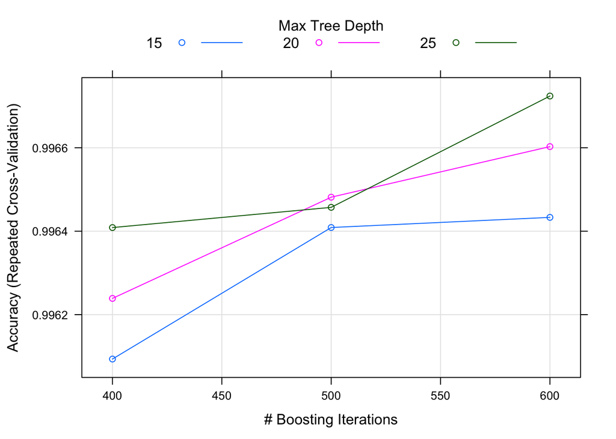

```r
plot(model_gbm)
```

```r
model_gbm
```

```
## Stochastic Gradient Boosting
##
## 13737 samples
##    52 predictor
##     5 classes: 'A', 'B', 'C', 'D', 'E'
##
## Pre-processing: centered (52), scaled (52)
## Resampling: Cross-Validated (10 fold, repeated 3 times)
## Summary of sample sizes: 12363, 12363, 12365, 12363, 12365, 12361, ...
## Resampling results across tuning parameters:
##
##   interaction.depth  n.trees  Accuracy   Kappa
##   15                 400      0.9960935  0.9950586
##   15                 500      0.9964089  0.9954575
##   15                 600      0.9964331  0.9954882
##   20                 400      0.9962389  0.9952426
##   20                 500      0.9964816  0.9955496
##   20                 600      0.9966028  0.9957029
##   25                 400      0.9964087  0.9954574
##   25                 500      0.9964572  0.9955187
##   25                 600      0.9967241  0.9958563
##
## Tuning parameter 'shrinkage' was held constant at a value of 0.1
##
## Tuning parameter 'n.minobsinnode' was held constant at a value of 10
## Accuracy was used to select the optimal model using  the largest value.
## The final values used for the model were n.trees = 600,
##  interaction.depth = 25, shrinkage = 0.1 and n.minobsinnode = 10.
```

```r
model_gbm$finalModel
```

```
## A gradient boosted model with multinomial loss function.
## 600 iterations were performed.
## There were 52 predictors of which 52 had non-zero influence.
```

This seems like a pretty good model with high accuracy. I think it will perform well on the test data.

#### Radial Support Vector Machine

```r
set.seed(168)
svm_ctrl <- trainControl(method = "repeatedcv", number = 10, repeats = 3, allowParallel=TRUE)
model_svm <- train(classe ~ ., data=train, method='svmRadial', preProcess = c("center", "scale"), trControl = svm_ctrl, tuneLength = 15)
```

On the first model build of the SVM I noticed that Accuracy kept increasing with larger values of C. I extended the tuneLength on the second run to 15 to see if I could find a peak.

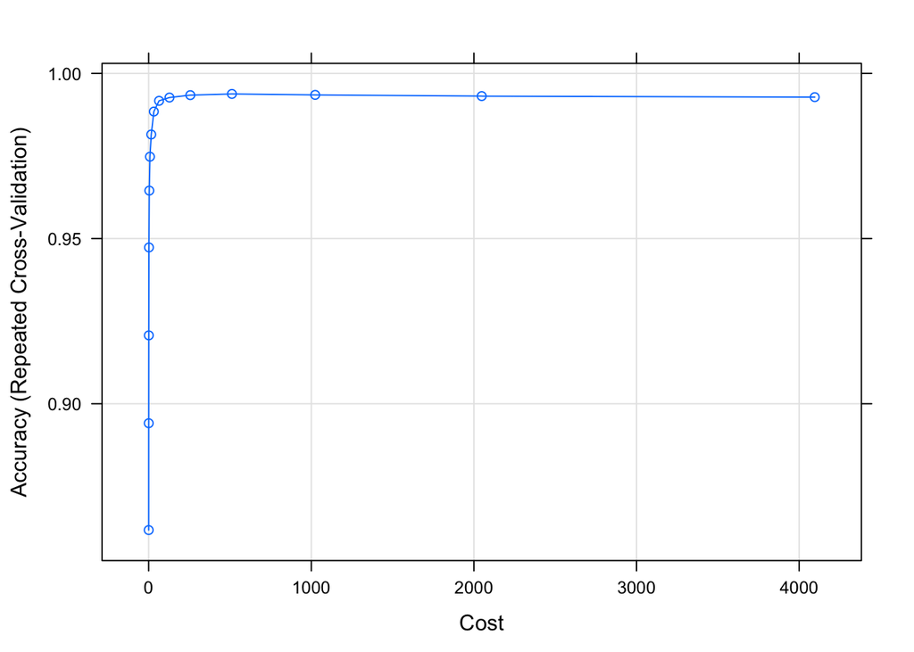

```r
plot(model_svm)
```

```r
model_svm
```

```
## Support Vector Machines with Radial Basis Function Kernel
##
## 13737 samples
##    52 predictor
##     5 classes: 'A', 'B', 'C', 'D', 'E'
##
## Pre-processing: centered (52), scaled (52)
## Resampling: Cross-Validated (10 fold, repeated 3 times)
## Summary of sample sizes: 12364, 12364, 12364, 12362, 12361, 12362, ...
## Resampling results across tuning parameters:
##
##   C        Accuracy   Kappa
##      0.25  0.8617614  0.8246990
##      0.50  0.8941061  0.8657177
##      1.00  0.9207006  0.8994769
##      2.00  0.9473195  0.9332658
##      4.00  0.9645236  0.9550778
##      8.00  0.9747880  0.9680860
##     16.00  0.9815102  0.9766016
##     32.00  0.9884500  0.9853869
##     64.00  0.9917019  0.9895028
##    128.00  0.9926966  0.9907611
##    256.00  0.9934249  0.9916825
##    512.00  0.9937885  0.9921426
##   1024.00  0.9934973  0.9917744
##   2048.00  0.9931337  0.9913144
##   4096.00  0.9928181  0.9909152
##
## Tuning parameter 'sigma' was held constant at a value of 0.01377062
## Accuracy was used to select the optimal model using  the largest value.
## The final values used for the model were sigma = 0.01377062 and C = 512.
```

There does appear to value here in in increasing the Cost value fairly high. The accuracy shoots up and quickly levels off and starts slowly decreasing. Around 512 appears to be optimal.

```r
model_svm$finalModel
```

```
## Support Vector Machine object of class "ksvm"
##
## SV type: C-svc  (classification)
##  parameter : cost C = 512
##
## Gaussian Radial Basis kernel function.
##  Hyperparameter : sigma =  0.0137706211520695
##
## Number of Support Vectors : 2877
##
## Objective Function Value : -10084.1 -1935.927 -1535.491 -606.0217 -5511.839 -1065.431 -1728.795 -36539.52 -2768.78 -8182.336
## Training error : 0.000582
```

The accuracy is realtively high, we will see how it performs on the validation data.

## Model Testing

Now let’s test our models against the validation data we held back to see how they perform.

```r
##Make predictions
predict_rf <- predict(model_rf,newdata = validation)
predict_gbm <- predict(model_gbm,newdata = validation)
predict_svm <- predict(model_svm,newdata = validation)

##Confusion Matrix for rf
confusionMatrix(predict_rf, validation$classe)
```

```
## Confusion Matrix and Statistics
##
##           Reference
## Prediction    A    B    C    D    E
##          A 1674    1    0    0    0
##          B    0 1138    2    0    0
##          C    0    0 1024    1    1
##          D    0    0    0  963    0
##          E    0    0    0    0 1081
##
## Overall Statistics
##
##                Accuracy : 0.9992
##                  95% CI : (0.998, 0.9997)
##     No Information Rate : 0.2845
##     P-Value [Acc > NIR] : < 2.2e-16
##
##                   Kappa : 0.9989
##  Mcnemar's Test P-Value : NA
##
## Statistics by Class:
##
##                      Class: A Class: B Class: C Class: D Class: E
## Sensitivity            1.0000   0.9991   0.9981   0.9990   0.9991
## Specificity            0.9998   0.9996   0.9996   1.0000   1.0000
## Pos Pred Value         0.9994   0.9982   0.9981   1.0000   1.0000
## Neg Pred Value         1.0000   0.9998   0.9996   0.9998   0.9998
## Prevalence             0.2845   0.1935   0.1743   0.1638   0.1839
## Detection Rate         0.2845   0.1934   0.1740   0.1636   0.1837
## Detection Prevalence   0.2846   0.1937   0.1743   0.1636   0.1837
## Balanced Accuracy      0.9999   0.9994   0.9988   0.9995   0.9995
```

```r
##Confusion Matrix for gbm
confusionMatrix(predict_gbm, validation$classe)
```

```
## Confusion Matrix and Statistics
##
##           Reference
## Prediction    A    B    C    D    E
##          A 1674    2    0    0    0
##          B    0 1136    1    0    0
##          C    0    1 1025    1    0
##          D    0    0    0  963    1
##          E    0    0    0    0 1081
##
## Overall Statistics
##
##                Accuracy : 0.999
##                  95% CI : (0.9978, 0.9996)
##     No Information Rate : 0.2845
##     P-Value [Acc > NIR] : < 2.2e-16
##
##                   Kappa : 0.9987
##  Mcnemar's Test P-Value : NA
##
## Statistics by Class:
##
##                      Class: A Class: B Class: C Class: D Class: E
## Sensitivity            1.0000   0.9974   0.9990   0.9990   0.9991
## Specificity            0.9995   0.9998   0.9996   0.9998   1.0000
## Pos Pred Value         0.9988   0.9991   0.9981   0.9990   1.0000
## Neg Pred Value         1.0000   0.9994   0.9998   0.9998   0.9998
## Prevalence             0.2845   0.1935   0.1743   0.1638   0.1839
## Detection Rate         0.2845   0.1930   0.1742   0.1636   0.1837
## Detection Prevalence   0.2848   0.1932   0.1745   0.1638   0.1837
## Balanced Accuracy      0.9998   0.9986   0.9993   0.9994   0.9995
```

```r
##Confusion Matrix for svm
confusionMatrix(predict_svm, validation$classe)
```

```
## Confusion Matrix and Statistics
##
##           Reference
## Prediction    A    B    C    D    E
##          A 1672    3    0    0    0
##          B    2 1135    1    0    1
##          C    0    0 1024    1    0
##          D    0    0    1  963    1
##          E    0    1    0    0 1080
##
## Overall Statistics
##
##                Accuracy : 0.9981
##                  95% CI : (0.9967, 0.9991)
##     No Information Rate : 0.2845
##     P-Value [Acc > NIR] : < 2.2e-16
##
##                   Kappa : 0.9976
##  Mcnemar's Test P-Value : NA
##
## Statistics by Class:
##
##                      Class: A Class: B Class: C Class: D Class: E
## Sensitivity            0.9988   0.9965   0.9981   0.9990   0.9982
## Specificity            0.9993   0.9992   0.9998   0.9996   0.9998
## Pos Pred Value         0.9982   0.9965   0.9990   0.9979   0.9991
## Neg Pred Value         0.9995   0.9992   0.9996   0.9998   0.9996
## Prevalence             0.2845   0.1935   0.1743   0.1638   0.1839
## Detection Rate         0.2841   0.1929   0.1740   0.1636   0.1835
## Detection Prevalence   0.2846   0.1935   0.1742   0.1640   0.1837
## Balanced Accuracy      0.9990   0.9978   0.9989   0.9993   0.9990
```

```r
###Rebuild GBM model with all training data
set.seed(336)
gbm_ctrl_final <- trainControl(method = "repeatedcv", number = 10, repeats = 3, allowParallel=TRUE)
gbm_grid_final <- expand.grid(interaction.depth = 25, shrinkage = .1, n.trees = 600, n.minobsinnode = 10)
model_gbm_final <- train(classe ~ ., data=training, method='gbm', preProcess = c("center", "scale"), trControl = gbm_ctrl_final, tuneGrid = gbm_grid_final, verbose = FALSE)
```

#### Testing

Now that I have my final model I can make my predictions for the test data which contains 20 samples.

```r
predict_gbm_final <- predict(model_gbm_final,newdata = testing)
```

The score was 20/20 for the models predictions. Given the high accuracy on the validation data this is not suprising.